# Good Plot, Bad Plot

Nikolas Yousefi

3/15/2021

# Libraries

```r
library(tidyverse)
library(here)
library(ggeasy)
library(extrafont)
library(ghibli)
library(viridis)
```

# Loading Data

```r
coffee_ratings <- read.csv(here("Week_7","Data","coffee_ratings.csv"))

glimpse(coffee_ratings)
```

```
## Rows: 1,339
## Columns: 43
## $ total_cup_points      <dbl> 90.58, 89.92, 89.75, 89.00, 88.83, 88.83, 88....
## $ species               <chr> "Arabica", "Arabica", "Arabica", "Arabica", "...
## $ owner                 <chr> "metad plc", "metad plc", "grounds for health...
## $ country_of_origin     <chr> "Ethiopia", "Ethiopia", "Guatemala", "Ethiopi...
## $ farm_name             <chr> "metad plc", "metad plc", "san marcos barranc...
## $ lot_number            <chr> NA, NA, NA, NA, NA, NA, NA, NA, NA, NA, NA, N...
## $ mill                  <chr> "metad plc", "metad plc", NA, "wolensu", "met...
## $ ico_number            <chr> "2014/2015", "2014/2015", NA, NA, "2014/2015"...
## $ company               <chr> "metad agricultural developmet plc", "metad a...
## $ altitude              <chr> "1950-2200", "1950-2200", "1600 - 1800 m", "1...
## $ region                <chr> "guji-hambela", "guji-hambela", NA, "oromia",...
## $ producer              <chr> "METAD PLC", "METAD PLC", NA, "Yidnekachew Da...
## $ number_of_bags        <int> 300, 300, 5, 320, 300, 100, 100, 300, 300, 50...
```

[output cut: 30 more lines]

# Analayzing Data

```r
coffee_clean <- coffee_ratings %>%
  select(total_cup_points, species, country_of_origin) %>% #Selecting data of interest
  filter(species == "Arabica") %>% # Picking only Arabica beans
  pivot_wider(names_from = species) %>% # Pivoting wider for easier analysis
  group_by(country_of_origin) %>% # Grouping to make getting mean easier
  summarise(mean_rating = mean(total_cup_points)) %>% # Getting mean of total cup points per country of origin
  drop_na() # Dropping any data with NAs
```

# Bad Plot

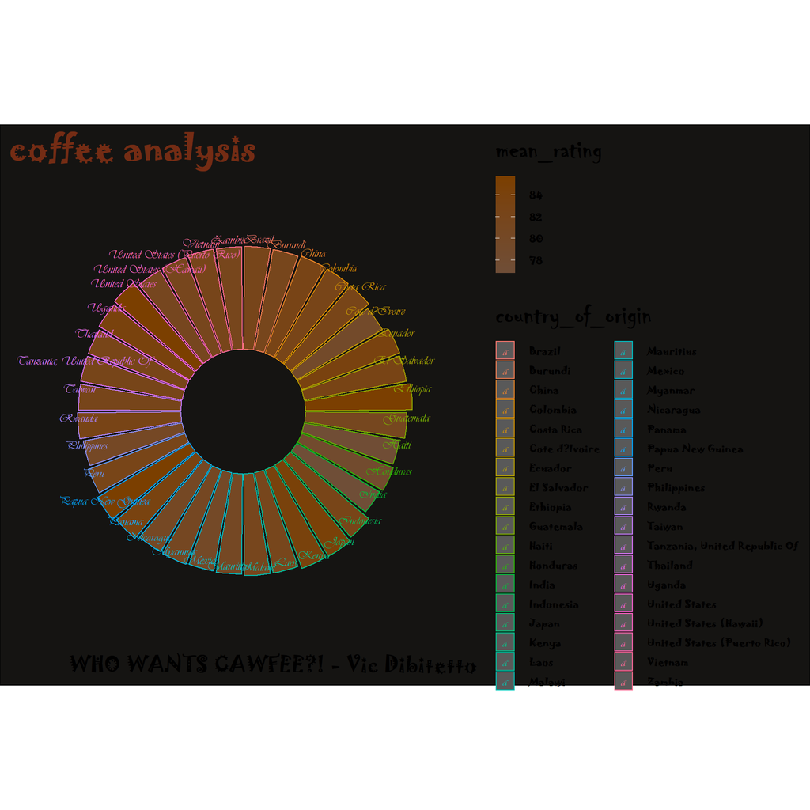

```r
ggplot(coffee_clean, aes(x=country_of_origin, y=mean_rating, fill = mean_rating, color = country_of_origin))+ # Setting up initial graph
  geom_bar(stat="identity")+ # Setting up as a bar graph
  theme_minimal() + # Minimal theme
  ylim(-50,100)+ # y-limit for making circular bar graph
  theme(text = element_text(family = "Jokerman",
                            face = "bold"), # Selecting font and bolding
    plot.background = element_rect(fill = ghibli_palette("TotoroDark")[c(2)]), # Filling background with a specific color
    plot.title = element_text(colour = ghibli_palette("MononokeMedium")[c(2)], size = 30), # Labeling plot title with a specific color
    plot.caption = element_text(size = 18), # Plot caption size
    legend.title = element_text(size = 25,
                                family = "Chiller"), # Legend title size and font type
    axis.text = element_blank(), # No axes text
    axis.title = element_blank(), # No axes titles
    panel.grid = element_blank())+ # No grid
coord_polar(start = 0)+ # Turning cartesian graph into a circular one
scale_fill_gradient(low = "#6F4E37", high = "#7B3F00")+ # Setting legend gradient
geom_text(data=coffee_clean,
          aes(x=country_of_origin,
              y=mean_rating,
              label=country_of_origin,
              hjust= 0.5,
              vjust = -0.5),
          family = "Vivaldi")+ # Setting up the circular bar plot font and adjusting text location
  labs(title = "coffee analysis",
       caption = "WHO WANTS CAWFEE?! - Vic Dibitetto")+ # Adding title and caption
  ggsave(here("Week_7", "Output", "badplot.png"),
         width = 10, height = 10) # Saving in specified area and at specific size
```

## Why this plot is bad

- Generic title that does not convey what the actual analysis is about
- Title also lacks proper capitalization
- Dark text against a dark background makes many of the words hard to read and is definitely not color-blind friendly
- Circular bar graph makes the data hard to interpret, especially with the lack of axes to determine what is being analyzed
- Multicolored text denoting the countries on the bar graph overlaps against one another and is not a standard font, making it near illegible
- Using a gradient to specify the means, especially one where the “low” and “high” colors are very similar, makes it hard to parse the data ; much of the data are also not whole numbers
- Useless legend denoting country of origin that not only uses a gradient style, making it hard to read, but also bleeds out of the graph
- Both legends also lack proper titles, instead opting for the ones directly used in the raw data
- Three different, non-standard font styles are used in the graph, legend, title, and caption
- The caption, which is usually meant to specify the source from which this data comes from, is replaced with a funny, but useless quote

# Good Plot

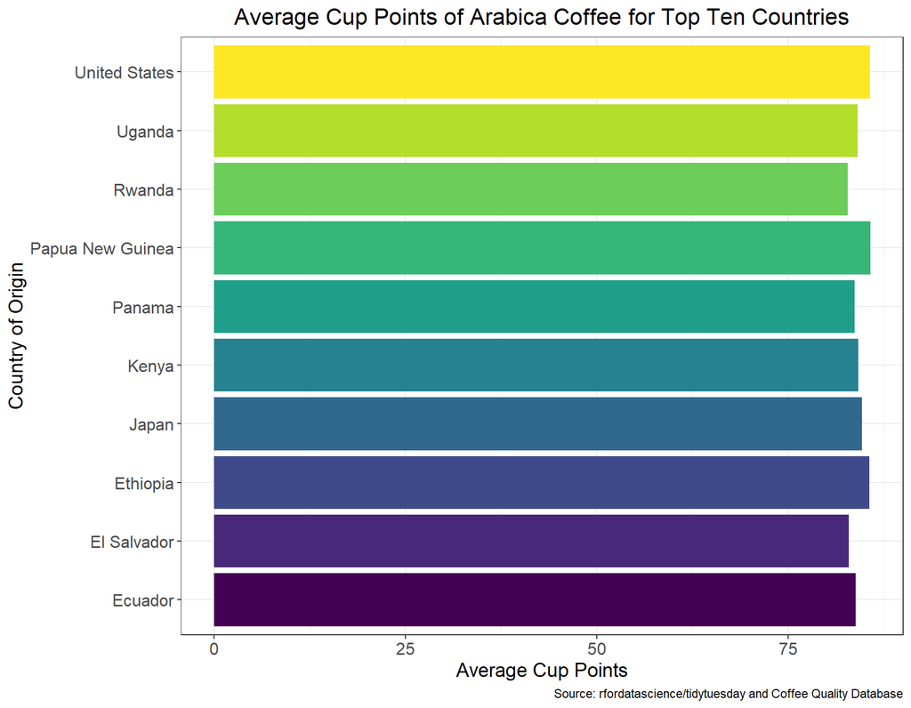

```r
coffeegood <- coffee_clean %>%
  filter(mean_rating >= 82.8300) # Filtering so only top 10 are included

ggplot(coffeegood, aes(x=country_of_origin, y=mean_rating, fill = country_of_origin))+ # Setting up the graph
  geom_bar(stat = "identity", show.legend = FALSE)+ # Using a bar graph for these data
  theme_bw()+ # Selecting a basic theme
  coord_flip()+ # Flipping axes
  scale_fill_viridis_d()+ # Going with a color-blind friendly color for the bars
  theme(plot.title = element_text(size = 16), # Changing title size
        axis.text = element_text(size = 12), # Changing text size of the axes text
        axis.title.x = element_text(size = 14), # Changing axis text size
        axis.title.y = element_text(size = 14))+ # Changing axis text size)
labs(x = "Country of Origin",
       y = "Average Cup Points",
       title = "Average Cup Points of Arabica Coffee for Top Ten Countries",
       caption = "Source: rfordatascience/tidytuesday and Coffee Quality Database")+ # Adding axes titles, as well as a graph title and caption
  ggeasy::easy_center_title()+ # Centering title
    ggsave(here("Week_7", "Output", "goodplot.png"),
         width = 9, height = 7) # Saving in specified area and at specific size
```

## Why this plot is good

- No vibrant-colored backgrounds or text making words or data hard to read or interpret
- While optional, the data has been cleaned and reduced so 30+ different countries of origin aren’t being graphed
- Title accurately states what the plot is looking to measure and visualize
- Axes are properly labeled
- Text is large, readable, and without distracting font types
- Bar graph colors are color-blind friendly
- No unnecessary legends
- Caption properly cites where the data was originally sourced from